# Puglisi_1744998_Torre_1546982

## PART 1: SELECTING DATA

For this assignment we decided to work with Depression data. As first we downloaded the ground truth data from the Behavioral Risk Factor Surveillance System, for the years from 2013 to 2016. Then we get the Google Trend data, selecting some keywords, related to the Depression desease. The keyword selected are: 'Panic','Zoloft','Lexapro','SSRI','Prozac','Cymbalta','Anxiety','Dopamine','Antidepressant','Self esteem','Happiness','Xanax','Pain', 'Irritability','Sad','Psychotherapy and 'Fatigue'.

We downloaded the data from Google using the Pytrends package, because it seemed to be more convenient and more efficient. However, during the performance of the task, we realized that Google Trends modifies the data (even those of years old) and that therefore, the results did not coincide with the previous days. So it's possible to have differences on results, but for day it changes just of few percent points for the predictions.Hence, the errors on the models can change, but the general results and the general considerations carried out definitely remain valid.

We built the following four datasets (df13, df14, df15, df16) having the Google Trend data for each year and for each state of the US. As first we fill the missing values with the mean of each state.

```python
from pytrends.request import TrendReq
import pandas as pd
from sklearn import linear_model
from math import sqrt
from sklearn.metrics import mean_squared_error
import numpy as np
import seaborn as sns
import matplotlib.pyplot as plt


pytrends = TrendReq(hl='US', tz=360)
df13 = pd.DataFrame()
df14 = pd.DataFrame()
df15 = pd.DataFrame()
df16 = pd.DataFrame()
kw_list = ['Panic',"Zoloft",'Lexapro',"SSRI",'Prozac','Cymbalta',"Anxiety","Dopamine","Antidepressant","Self esteem",
           "Happiness","Xanax","Pain","Irritability","Sad","Psychotherapy","Fatigue"]
for i in kw_list:

    pytrends.build_payload([i], cat=45, timeframe='2013-01-01 2013-12-31', geo='US', gprop='')
    df13=pd.concat([df13,pytrends.interest_by_region(resolution='COUNTRY')],axis=1)

    pytrends.build_payload([i], cat=45, timeframe='2014-01-01 2014-12-31', geo='US', gprop='')
    df14=pd.concat([df14,pytrends.interest_by_region(resolution='COUNTRY')],axis=1)

    pytrends.build_payload([i], cat=45, timeframe='2015-01-01 2015-12-31', geo='US', gprop='')
    df15=pd.concat([df15,pytrends.interest_by_region(resolution='COUNTRY')],axis=1)

    pytrends.build_payload([i], cat=45, timeframe='2016-01-01 2016-12-31', geo='US', gprop='')
    df16=pd.concat([df16,pytrends.interest_by_region(resolution='COUNTRY')],axis=1)
```

```python
df13.fillna(df13.mean(axis=0),inplace=True)
df14.fillna(df14.mean(axis=0),inplace=True)
df15.fillna(df15.mean(axis=0),inplace=True)
df16.fillna(df16.mean(axis=0),inplace=True)
```

| geoName | Panic | Zoloft | Lexapro | SSRI | Prozac | Cymbalta | Anxiety | Dopamine | Antidepressant | Self esteem | Happiness | Xanax | Pain | Irritability | Sad | Psychotherapy | Fatigue |
| --- | --- | --- | --- | --- | --- | --- | --- | --- | --- | --- | --- | --- | --- | --- | --- | --- | --- |
| Alabama | 93 | 96 | 90 | 46 | 75 | 77 | 85 | 70 | 68 | 33.000000 | 49.0 | 90 | 93 | 79.0000 | 41 | 26 | 83 |
| Alaska | 60 | 47 | 76 | 60 | 54 | 32 | 73 | 64 | 82 | 36.000000 | 84.0 | 62 | 78 | 67.0625 | 53 | 60 | 89 |
| Arizona | 62 | 66 | 52 | 47 | 51 | 53 | 82 | 80 | 54 | 30.000000 | 55.0 | 78 | 81 | 69.0000 | 46 | 36 | 81 |
| Arkansas | 72 | 90 | 68 | 40 | 79 | 73 | 81 | 75 | 70 | 27.000000 | 52.0 | 88 | 91 | 73.0000 | 37 | 21 | 83 |
| California | 57 | 53 | 42 | 40 | 48 | 36 | 74 | 71 | 47 | 32.000000 | 61.0 | 66 | 65 | 51.0000 | 46 | 31 | 68 |
| Carolina del Nord | 75 | 83 | 60 | 49 | 67 | 60 | 77 | 68 | 60 | 24.000000 | 62.0 | 77 | 84 | 75.0000 | 47 | 33 | 77 |
| Carolina del Sud | 81 | 75 | 69 | 51 | 69 | 66 | 79 | 61 | 54 | 15.000000 | 53.0 | 82 | 86 | 97.0000 | 44 | 36 | 77 |
| Colorado | 90 | 67 | 46 | 49 | 51 | 50 | 76 | 74 | 65 | 25.000000 | 49.0 | 57 | 69 | 60.0000 | 47 | 37 | 78 |
| Connecticut | 71 | 73 | 91 | 61 | 63 | 69 | 93 | 92 | 60 | 30.000000 | 58.0 | 67 | 81 | 90.0000 | 51 | 52 | 85 |
| Dakota del Nord | 65 | 80 | 58 | 51 | 78 | 64 | 89 | 100 | 93 | 32.244898 | 33.0 | 46 | 81 | 77.0000 | 93 | 36 | 72 |
| Dakota del Sud | 64 | 75 | 63 | 41 | 79 | 60 | 82 | 71 | 68 | 45.000000 | 56.1 | 42 | 81 | 74.0000 | 35 | 34 | 69 |
| Delaware | 56 | 73 | 56 | 50 | 46 | 56 | 81 | 78 | 42 | 70.000000 | 98.0 | 69 | 89 | 67.0625 | 47 | 44 | 73 |
| Distretto di Columbia | 60 | 84 | 72 | 58 | 45 | 47 | 77 | 66 | 58 | 29.000000 | 52.0 | 75 | 71 | 58.0000 | 53 | 27 | 71 |
| Florida | 60 | 63 | 55 | 39 | 54 | 51 | 73 | 78 | 54 | 25.000000 | 50.0 | 77 | 72 | 59.0000 | 37 | 20 | 69 |
| Georgia | 79 | 75 | 64 | 39 | 65 | 55 | 77 | 63 | 53 | 34.000000 | 42.0 | 86 | 80 | 61.0000 | 47 | 23 | 78 |
| Hawaii | 52 | 47 | 32 | 34 | 42 | 31 | 68 | 71 | 34 | 37.000000 | 67.0 | 57 | 68 | 69.0000 | 47 | 16 | 66 |
| Idaho | 69 | 60 | 55 | 39 | 64 | 63 | 85 | 81 | 64 | 27.000000 | 100.0 | 55 | 77 | 71.0000 | 63 | 22 | 78 |
| Illinois | 69 | 70 | 61 | 54 | 51 | 51 | 82 | 63 | 54 | 28.000000 | 59.0 | 78 | 75 | 66.0000 | 51 | 33 | 70 |
| Indiana | 64 | 88 | 78 | 49 | 71 | 76 | 83 | 69 | 73 | 34.000000 | 43.0 | 78 | 84 | 61.0000 | 48 | 15 | 83 |
| Iowa | 65 | 72 | 58 | 52 | 64 | 49 | 81 | 60 | 48 | 40.000000 | 48.0 | 54 | 79 | 60.0000 | 50 | 35 | 81 |
| Kansas | 61 | 78 | 55 | 49 | 55 | 63 | 74 | 72 | 75 | 27.000000 | 30.0 | 70 | 74 | 62.0000 | 37 | 27 | 69 |
| Kentucky | 77 | 100 | 70 | 61 | 81 | 76 | 96 | 91 | 76 | 19.000000 | 60.0 | 75 | 97 | 57.0000 | 45 | 24 | 84 |
| Louisiana | 64 | 82 | 84 | 47 | 69 | 72 | 81 | 65 | 59 | 23.000000 | 58.0 | 93 | 86 | 71.0000 | 42 | 8 | 76 |
| Maine | 73 | 79 | 56 | 65 | 57 | 54 | 96 | 91 | 67 | 37.000000 | 43.0 | 47 | 85 | 70.0000 | 65 | 18 | 93 |
| Maryland | 59 | 73 | 64 | 58 | 52 | 47 | 79 | 83 | 60 | 32.000000 | 52.0 | 60 | 76 | 88.0000 | 49 | 46 | 75 |
| Massachusetts | 70 | 79 | 41 | 71 | 69 | 44 | 91 | 78 | 65 | 32.000000 | 60.0 | 54 | 75 | 70.0000 | 56 | 56 | 78 |
| Michigan | 72 | 88 | 62 | 49 | 70 | 78 | 88 | 73 | 63 | 20.000000 | 48.0 | 89 | 83 | 63.0000 | 56 | 20 | 82 |
| Minnesota | 68 | 74 | 49 | 47 | 65 | 47 | 89 | 67 | 56 | 29.000000 | 81.0 | 53 | 77 | 94.0000 | 73 | 41 | 82 |
| Mississippi | 100 | 84 | 84 | 49 | 80 | 81 | 90 | 72 | 66 | 31.000000 | 37.0 | 90 | 91 | 76.0000 | 36 | 35 | 96 |
| Missouri | 70 | 74 | 65 | 56 | 66 | 70 | 79 | 69 | 68 | 38.000000 | 62.0 | 80 | 82 | 56.0000 | 52 | 26 | 74 |
| Montana | 75 | 72 | 59 | 49 | 63 | 97 | 79 | 71 | 84 | 28.000000 | 92.0 | 43 | 82 | 78.0000 | 84 | 57 | 100 |
| Nebraska | 61 | 61 | 67 | 39 | 53 | 57 | 84 | 83 | 57 | 30.000000 | 42.0 | 69 | 77 | 38.0000 | 43 | 19 | 77 |
| Nevada | 62 | 52 | 32 | 45 | 45 | 40 | 76 | 62 | 44 | 30.000000 | 42.0 | 77 | 72 | 54.0000 | 40 | 25 | 68 |
| New Hampshire | 62 | 96 | 73 | 80 | 84 | 70 | 96 | 95 | 93 | 28.000000 | 39.0 | 48 | 86 | 56.0000 | 53 | 17 | 87 |
| New Jersey | 62 | 72 | 72 | 51 | 51 | 45 | 76 | 68 | 57 | 43.000000 | 62.0 | 72 | 78 | 59.0000 | 51 | 36 | 72 |
| New York | 58 | 62 | 57 | 50 | 52 | 47 | 77 | 73 | 52 | 30.000000 | 50.0 | 70 | 71 | 52.0000 | 43 | 61 | 67 |
| Nuovo Messico | 64 | 67 | 35 | 31 | 45 | 44 | 81 | 61 | 67 | 19.000000 | 60.0 | 59 | 77 | 23.0000 | 36 | 28 | 71 |
| Ohio | 67 | 92 | 65 | 54 | 70 | 68 | 84 | 73 | 65 | 20.000000 | 59.0 | 71 | 86 | 72.0000 | 58 | 20 | 81 |
| Oklahoma | 53 | 85 | 52 | 44 | 64 | 78 | 89 | 83 | 71 | 31.000000 | 46.0 | 83 | 88 | 85.0000 | 28 | 10 | 82 |
| Oregon | 65 | 58 | 45 | 53 | 54 | 63 | 81 | 85 | 64 | 36.000000 | 50.0 | 54 | 73 | 64.0000 | 80 | 29 | 87 |
| Pennsylvania | 75 | 94 | 78 | 65 | 68 | 72 | 94 | 82 | 64 | 38.000000 | 42.0 | 72 | 87 | 72.0000 | 50 | 35 | 85 |
| Rhode Island | 54 | 81 | 54 | 80 | 87 | 52 | 95 | 97 | 59 | 40.000000 | 65.0 | 66 | 81 | 100.0000 | 70 | 61 | 79 |
| Tennessee | 88 | 93 | 70 | 55 | 71 | 78 | 85 | 79 | 66 | 15.000000 | 35.0 | 83 | 89 | 58.0000 | 44 | 25 | 84 |
| Texas | 56 | 60 | 52 | 37 | 47 | 50 | 71 | 67 | 48 | 26.000000 | 43.0 | 76 | 69 | 52.0000 | 43 | 24 | 67 |
| Utah | 57 | 70 | 56 | 52 | 62 | 68 | 83 | 80 | 68 | 42.000000 | 90.0 | 59 | 74 | 83.0000 | 52 | 38 | 79 |
| Vermont | 78 | 69 | 55 | 69 | 75 | 42 | 92 | 89 | 100 | 100.000000 | 52.0 | 41 | 76 | 61.0000 | 100 | 100 | 95 |
| Virginia | 70 | 79 | 59 | 49 | 61 | 62 | 75 | 77 | 57 | 25.000000 | 56.0 | 63 | 78 | 70.0000 | 50 | 49 | 82 |
| Virginia Occidentale | 86 | 100 | 100 | 56 | 100 | 100 | 100 | 60 | 71 | 37.000000 | 34.0 | 100 | 100 | 60.0000 | 75 | 19 | 82 |
| Washington | 59 | 68 | 41 | 55 | 57 | 40 | 81 | 76 | 59 | 28.000000 | 55.0 | 56 | 74 | 72.0000 | 66 | 27 | 84 |
| Wisconsin | 72 | 58 | 48 | 43 | 56 | 46 | 85 | 83 | 59 | 25.000000 | 49.0 | 53 | 82 | 53.0000 | 63 | 54 | 80 |
| Wyoming | 63 | 72 | 54 | 100 | 58 | 55 | 81 | 89 | 34 | 32.244898 | 96.0 | 60 | 81 | 67.0625 | 46 | 52 | 87 |

Also for the ground truth data we created two datasets for different indicators: Age-adjusted prevalence and Crude prevalence, that we joined to the keywords datasets for each year.

```python
crude = pd.read_csv("total.csv", sep =";")
crude.index = crude.iloc[:,0]
crude = crude.sort_index(axis=0)
crude=pd.DataFrame(crude.iloc[:,1:5], index=crude.index)

adj = pd.read_csv("AdjAgest1.csv", sep =";")
adj.index = adj.iloc[:, 0]
adj = adj.sort_index(axis=0)
adj=pd.DataFrame(adj.iloc[:,1:5], index=adj.index)
```

```python
trediciC = pd.concat([df13, crude.iloc[:,0]], axis= 1)
quattordiciC = pd.concat([df14, crude.iloc[:,1]], axis= 1)
quindiciC = pd.concat([df15, crude.iloc[:,2]], axis= 1)
sediciC = pd.concat([df16, crude.iloc[:,3]], axis= 1)

trediciA = pd.concat([df13, adj.iloc[:,0]], axis= 1)
quattordiciA = pd.concat([df14, adj.iloc[:,1]], axis= 1)
quindiciA = pd.concat([df15, adj.iloc[:,2]], axis= 1)
sediciA = pd.concat([df16, adj.iloc[:,3]], axis= 1)
```

# 1.1: CORRELATION STUDY

```python
Correlation = pd.DataFrame([trediciC.corr().loc[:,"2013"],
                            trediciA.corr().loc[:,"2013"],
                           quattordiciC.corr().loc[:,"2014"],
                            quattordiciA.corr().loc[:,"2014"],
                            quindiciC.corr().loc[:,"2015"],
                            quindiciA.corr().loc[:,"2015"],
                            sediciC.corr().loc[:,"2016"],
                            sediciA.corr().loc[:,"2016"]], columns = df16.columns,
                           index = ["Crude2013","Adj2013","Crude2014","Adj2014","Crude2015","Adj2015",
                                   "Crude2016","Adj2016"])
Correlation.iloc[:,:]
```

|  | Panic | Zoloft | Lexapro | SSRI | Prozac | Cymbalta | Anxiety | Dopamine | Antidepressant | Self esteem | Happiness | Xanax | Pain | Irritability | Sad | Psychotherapy | Fatigue |
| --- | --- | --- | --- | --- | --- | --- | --- | --- | --- | --- | --- | --- | --- | --- | --- | --- | --- |
| Crude2013 | 0.212659 | 0.261830 | -0.043118 | 0.272388 | 0.331488 | 0.208917 | 0.238527 | 0.285295 | 0.291051 | -0.307058 | -0.050582 | -0.075716 | 0.132113 | 0.202920 | 0.095468 | 0.037810 | 0.347269 |
| Adj2013 | 0.187736 | 0.255155 | -0.055494 | 0.280449 | 0.331572 | 0.201272 | 0.242277 | 0.276051 | 0.288943 | -0.316644 | -0.042061 | -0.097703 | 0.121879 | 0.204684 | 0.105300 | 0.042819 | 0.337832 |
| Crude2014 | 0.387158 | 0.408088 | 0.221216 | 0.221232 | 0.654063 | 0.499675 | 0.454807 | 0.081411 | 0.143543 | -0.068268 | 0.020294 | 0.000345 | 0.362886 | 0.106407 | 0.191611 | 0.008783 | 0.401448 |
| Adj2014 | 0.381689 | 0.403780 | 0.205042 | 0.226004 | 0.653679 | 0.494115 | 0.471156 | 0.092922 | 0.150640 | -0.083433 | 0.033640 | -0.034126 | 0.356712 | 0.107853 | 0.207952 | 0.019092 | 0.416905 |
| Crude2015 | 0.444218 | 0.431516 | 0.124038 | 0.367946 | 0.524999 | 0.425465 | 0.316748 | 0.203250 | 0.472891 | 0.011877 | 0.136024 | -0.055278 | 0.280860 | 0.221598 | -0.061378 | -0.015251 | 0.475998 |
| Adj2015 | 0.443352 | 0.440453 | 0.119612 | 0.382874 | 0.525833 | 0.410338 | 0.336549 | 0.205856 | 0.472597 | 0.018961 | 0.155976 | -0.088333 | 0.274402 | 0.218951 | -0.044196 | -0.010917 | 0.494961 |
| Crude2016 | 0.403850 | 0.545346 | 0.211350 | 0.267934 | 0.574292 | 0.551922 | 0.590890 | 0.230670 | 0.458526 | 0.032533 | -0.157163 | 0.183160 | 0.555600 | 0.178922 | 0.234047 | -0.121937 | 0.532908 |
| Adj2016 | 0.392751 | 0.547414 | 0.202860 | 0.296691 | 0.582985 | 0.543823 | 0.617141 | 0.261276 | 0.475020 | 0.056680 | -0.157458 | 0.142040 | 0.552657 | 0.173467 | 0.263167 | -0.109311 | 0.551981 |

## 1.2: POVERTY AND INCOME

```python
Poverty = pd.read_csv("poverty.csv", sep =";")
Poverty.index = Poverty.loc[:,'State / County Name']
Poverty = Poverty.sort_index(axis=0)
Poverty.drop(['State / County Name'], axis=1, inplace=True)
PovertyAdj = pd.concat([Poverty,adj.iloc[:,:]], axis=1)
PovertyCr = pd.concat([Poverty,crude.iloc[:,:]], axis=1)
```

```python
PovertyAdj.corr().iloc[0:8,-4:]
PovertyCr.corr().iloc[0:8,-4:]
```

|  | 2013 | 2014 | 2015 | 2016 |
| --- | --- | --- | --- | --- |
| Poverty2013 | 0.240281 | 0.304651 | 0.220658 | 0.299994 |
| Income2013 | -0.422094 | -0.531402 | -0.481828 | -0.477518 |
| Poverty2014 | 0.227589 | 0.305461 | 0.219644 | 0.303392 |
| Income2014 | -0.415188 | -0.526828 | -0.476576 | -0.483435 |
| Poverty2015 | 0.218503 | 0.300660 | 0.208143 | 0.293003 |
| Income2015 | -0.403605 | -0.521123 | -0.466514 | -0.466416 |
| Poverty2016 | 0.210786 | 0.296046 | 0.199003 | 0.273810 |
| Income2016 | -0.393397 | -0.512174 | -0.461048 | -0.457066 |

## PART 2: PREDICTION MODEL

For the prediction we use two kind of crossvalidation: Temporal, to predict the morbidity rate on a given year and Spatial, to predict the morbidity rate on a given State.

# Temporal Predictions

We started with the prediction on the Age prevalence target. As first we normalized data using standard normalization. Then we chose to compute the prediction on 2014, 2015, 2016. To do this we built the datasets in this way: for each of the three prediction, we concatenated the rows of the dataframe having all the keywords and the real data. So that, we predict the given year on the basis of the previous ones. As result, we get three dataframes called "TrendTot"(for the prediction on 2016),"TrendTotN13" (for the prediction on 2014),"TrendTotN14" (for the prediction on 2015), we decided to use these as training set. The test set are called "Target", "TargetN13", "TargetN14", regarding the year chosen for the prediction.

```python
df13 = (df13 - df13.mean())/df13.std()
df14 = (df14 - df14.mean())/df14.std()
df15 = (df15 - df15.mean())/df15.std()
df16 = (df16 - df16.mean())/df16.std()
adj = (adj - adj.mean())/adj.std()
crude = (crude - crude.mean())/crude.std()
```

```python
TrendTot = pd.concat([df13,df14, df15],axis=0)
anniAdj = pd.concat([adj.iloc[:,0],adj.iloc[:,1],adj.iloc[:,2]],axis=0)
TrendTot = pd.concat([TrendTot,anniAdj],axis=1)
Target= pd.concat([df16,adj.iloc[:,-1]],axis=1)
```

To assign more weight to each State, we created 51 dummies having value 1 only if that observation belongs to the state of the dummy.

```python
TrendTot.reset_index(inplace=True)
df = pd.get_dummies(TrendTot["index"])
TrendTot = pd.concat([df,TrendTot],axis=1)
TrendTot.drop(["index"],axis=1,inplace=True)
```

```python
Target.reset_index(inplace=True)
df1 = pd.get_dummies(Target["index"])
Target = pd.concat([df1,Target],axis=1)
Target.drop(["index"],axis=1,inplace=True)
```

## 2.1 : Prediction

Below we can see the predictions, using the lasso method with Leave One Out Crossvalidation. We used 2 indexes to check the correctness of our model, Rsquare and RMSE. As we can see, the model on 2014 doesn't fit well, with a very low Rsquare and high RMSE. The model on 2015 seems very efficient, in fact RMSE decrease surprisingly and the Rsquare increase a lot. Although in the 2016 predictions get worse, with an RMSE almost of the 50% and 70% in mean for Rsquare.

```python
TrendTotN13=TrendTot.iloc[0:51,:]
TargetN13=TrendTot.iloc[51:102,:]
lasso = linear_model.LassoCV(cv=TrendTotN13.shape[0], max_iter=10000)
X = TrendTotN13.iloc[:,0:-1]
y = TrendTotN13.iloc[:,-1]
lasso.fit(X,y)
s = lasso.predict(TargetN13.iloc[:,0:-1])
rmse = sqrt(mean_squared_error(TargetN13.iloc[:,-1], s))

print("The RMSE is", rmse)
print("The Rsquare is " , lasso.score(TargetN13.iloc[:,0:-1],TargetN13.iloc[:,-1]))
```

```
The RMSE is 0.8764582029350277
The Rsquare is  0.216457438878
```

```python
TrendTotN14=TrendTot.iloc[0:102,:]
TargetN14=TrendTot.iloc[102:153,:]
lasso = linear_model.LassoCV(cv=TrendTotN14.shape[0], max_iter=10000)
X = TrendTotN14.iloc[:,0:-1]
y = TrendTotN14.iloc[:,-1]
lasso.fit(X,y)
s = lasso.predict(TargetN14.iloc[:,0:-1])
rmse = sqrt(mean_squared_error(TargetN14.iloc[:,-1], s))

print("The RMSE is", rmse)
print("The Rsquare is " , lasso.score(TargetN14.iloc[:,0:-1],TargetN14.iloc[:,-1]))
```

```
The RMSE is 0.3662308751155529
The Rsquare is  0.863192445034
```

```python
lasso = linear_model.LassoCV(cv=TrendTot.shape[0], max_iter=10000)
X = TrendTot.iloc[:,0:-1]
y = TrendTot.iloc[:,-1]
lasso.fit(X,y)
s = lasso.predict(Target.iloc[:,0:-1])
rmse = sqrt(mean_squared_error(Target.iloc[:,-1], s))

print("The RMSE is", rmse)
print("The Rsquare is " , lasso.score(Target.iloc[:,0:-1],Target.iloc[:,-1]))
```

```
The RMSE is 0.5230233089463455
The Rsquare is  0.720975550665
```

## SPATIAL CROSS VALIDATION

Now we prepare data for the spatial cross validation. As first we joined by rows the four datasets (for 2013,2014,2015,2016) having the same variables and then we ordered by states. The dataset is in the form showed below:

```python
Spatial = pd.concat([df13,df14, df15, df16],axis=0)
anniAdj = pd.concat([adj.iloc[:,0],adj.iloc[:,1],adj.iloc[:,2],adj.iloc[:,-1]],axis=0)
Spatial = pd.concat([Spatial,anniAdj],axis=1)
Spatial = Spatial.sort_index()
Spatial.reset_index(inplace=True)
df11 = pd.get_dummies(Spatial["index"])

Spatial = pd.concat([df11,Spatial],axis=1)
Spatial.index=Spatial["index"]
Spatial.drop(["index"],axis=1,inplace=True)
states = set(Spatial.index)
```

After this we applied a crossvalidation Leave One Out for State. We want to predict the morbidity rate on a country for the four years cosidered, so we use as training set the remaining 50 States with their different values in the 4 years, instead as test set there are 4 rows of the given state. In this case predictions doesn't fit well, as we can see from the RMSE, this is why we can't generalize the morbidity rate on the US in a spatial way, because each State is determined from factor (e.g. how much time people spends doing online research) that are different from state by state. It means that, if model doesn't know totally the behaviour of disease in a State, neither in other years, predictions on that states are not reliable.

```python
score = []
rmse=[]
lasso = linear_model.LassoCV(cv=50)
for c in states:
    X_train = Spatial[Spatial.index != c].iloc[:,0:-1]
    Y_train = Spatial.iloc[Spatial.index != c].iloc[:,-1]
    X_test = Spatial[Spatial.index == c].iloc[:,0:-1]
    Y_test = Spatial[Spatial.index == c].iloc[:,-1]
    lasso.fit(X_train,Y_train)
    s = lasso.predict(X_test)
    rmse.append(sqrt(mean_squared_error(Y_test, s)))

print("The mean RMSE is", np.mean(rmse))
```

```
The mean RMSE is 0.713260148918
```

Here we can see the boxplot of the 51 RMSE generated from this last CV per state. As we have just said, there are some states too difficult to predict with a spatial CV, we can see this looking to the outliers states in the boxplot.

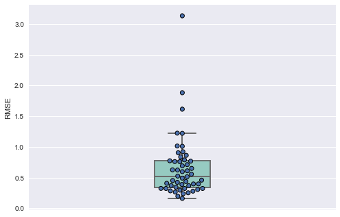

```python
sns.boxplot(data=rmse, width=.18,palette="Set3")
sns.swarmplot(data=rmse, size=6, edgecolor="black", linewidth=1,split=False,  y="RMSE")
sns.plt.show()
```

In the dataframe below we see the outliers State shown in the boxplot. The values of the RMSE are high, which explains the fact that we can't create an exact model for this type of prediction.

```python
state= pd.DataFrame(sorted(list(states)), columns=["States"])
rmse= pd.DataFrame(rmse, columns=["RMSE"])
rmse = pd.concat([state,rmse],axis=1)
rmse.sort_values(["RMSE"],ascending=False).iloc[:2,:]
```

|  | States | RMSE |
| --- | --- | --- |
| 33 | New Hampshire | 3.131448 |
| 43 | Texas | 1.880609 |

## Prediction with Crude Prevalence

Now we can see the same procedure for the Crude prevalence, we begin with Temporal Crossvalidation for the year 2016. The crude prevalence is not a weighted average as the age adjusted prevalence, so it's less accurated then the previous one. In fact Age adjusted prevalence rates is a way to make fairer comparisons between groups with different age distributions. For example, a county having a higher percentage of elderly people may have a higher rate of death or hospitalization than a county with a younger population, merely because the old people are more likely to die or be hospitalized. In the light of this, we have that results show that the RMSE for the Crude prevalence is higher, and the Rsquare is lower. So we can conclude that using an age prevalnce gives more accurate predictions.

```python
TrendTot1= TrendTot.iloc[:,:-1]
anniCr = pd.DataFrame(pd.concat([crude.iloc[:,0],crude.iloc[:,1],crude.iloc[:,2]],axis=0),columns=["Years"])
TrendTot1['Years'] = anniCr.values
Target1=Target.iloc[:,:-1]
Target1.index=df16.index
Target1['Years'] = crude.iloc[:,-1]
```

```python
lasso = linear_model.LassoCV(cv=TrendTot1.shape[0],max_iter=10000)
X = TrendTot1.iloc[:,0:-1]
y = TrendTot1.iloc[:,-1]
lasso.fit(X,y)
s = lasso.predict(Target1.iloc[:,0:-1])
rms = sqrt(mean_squared_error(Target1.iloc[:,-1], s))

print("The RMSE is", rms)
print("The Rsquare is " , lasso.score(Target1.iloc[:,0:-1],Target1.iloc[:,-1]))
```

```
The RMSE is 0.5332448628750613
The Rsquare is  0.709962914542
```

```python
Spatial1 = pd.concat([df13,df14, df15, df16],axis=0)
anniAdj1 = pd.concat([crude.iloc[:,0],crude.iloc[:,1],crude.iloc[:,2],crude.iloc[:,-1]],axis=0)
Spatial1 = pd.concat([Spatial1,anniAdj1],axis=1)
Spatial1 = Spatial.sort_index()
Spatial1.reset_index(inplace=True)
df11 = pd.get_dummies(Spatial1["index"])

Spatial1 = pd.concat([df11,Spatial1],axis=1)
Spatial1.index=Spatial1["index"]
Spatial1.drop(["index"],axis=1,inplace=True)
states = set(Spatial1.index)
rmse=[]
lasso = linear_model.LassoCV(cv=50)
for c in states:
    X_train = Spatial1[Spatial1.index != c].iloc[:,0:-1]
    Y_train = Spatial1.iloc[Spatial1.index != c].iloc[:,-1]
    X_test = Spatial1[Spatial1.index == c].iloc[:,0:-1]
    Y_test = Spatial1[Spatial1.index == c].iloc[:,-1]
    lasso.fit(X_train,Y_train)
    s = lasso.predict(X_test)
    rmse.append(sqrt(mean_squared_error(Y_test, s)))

print("The mean RMSE is",np.mean(rmse))
```

```
The mean RMSE is 0.713260253244
```

## Selection of the Best Model

At this point we asked ourselves: which are the variables that explain better our model and instead which variables are unnecessary? So we decided to select variables using 3 kind of techniques:

1) Correlation: below we plot the correlation matrix which explains the correlation between all the variables. Then we dropped the variables that are more correlated (correlation bigger than 0.6), because these don't add more information. We select the Age prevalence data as target.

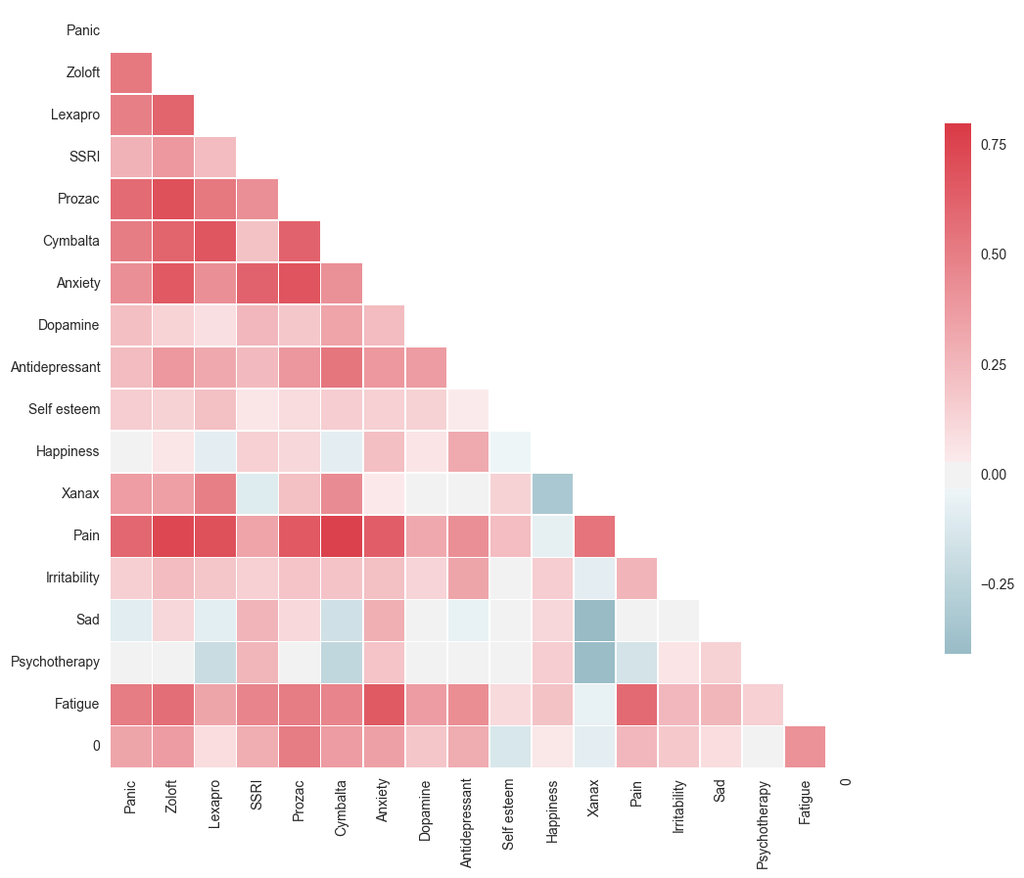

```python
sns.set(style="white")
corr=TrendTot.iloc[:,51:]
mask = np.zeros_like(corr.corr(), dtype=np.bool)
mask[np.triu_indices_from(mask)] = True
f, ax = plt.subplots(figsize=(20, 10))
sns.heatmap(corr.corr(), mask=mask, cmap=sns.diverging_palette(220, 10, as_cmap=True),vmax=.8, center=0,
            square=True, linewidths=.5, cbar_kws={"shrink": .7})
plt.show()
```

As this plot shows, there are some strong correlation, in particular between Pain with the most part of variables. So looking for the variables having an absolute correlation bigger than 60%, we decided to drop 3 columns.

```python
corr_matrix = corr.corr().abs()
high_corr_var=np.where(corr_matrix>0.6)
high_corr_var=[(corr_matrix.index[x],corr_matrix.columns[y]) for x,y in zip(*high_corr_var) if x!=y and x<y]
high_corr_var
```

```
[('Panic', 'Pain'),
 ('Zoloft', 'Lexapro'),
 ('Zoloft', 'Prozac'),
 ('Zoloft', 'Cymbalta'),
 ('Zoloft', 'Anxiety'),
 ('Zoloft', 'Pain'),
 ('Lexapro', 'Cymbalta'),
 ('Lexapro', 'Pain'),
 ('SSRI', 'Anxiety'),
 ('Prozac', 'Cymbalta'),
 ('Prozac', 'Anxiety'),
 ('Prozac', 'Pain'),
 ('Cymbalta', 'Pain'),
 ('Anxiety', 'Pain'),
 ('Anxiety', 'Fatigue')]
```

Applying the Lasso CV, we obtained better predictions for the Age Adjusted Prevalence than the first prediction on the 2016.

```python
trendtotcor=TrendTot.drop(['Pain', 'Anxiety','Cymbalta'], axis=1)
targetcorr=Target.drop(['Pain', 'Anxiety', 'Cymbalta'], axis=1)

lasso = linear_model.LassoCV(cv=trendtotcor.shape[0],max_iter=10000)
X = trendtotcor.iloc[:,0:-1]
y = trendtotcor.iloc[:,-1]
lasso.fit(X,y)
s = lasso.predict(targetcorr.iloc[:,0:-1])
rmse = sqrt(mean_squared_error(targetcorr.iloc[:,-1], s))
print("The RMSE is", rmse)
print("The Rsquare is " , lasso.score(targetcorr.iloc[:,0:-1],targetcorr.iloc[:,-1]))
```

```
The RMSE is 0.5171168704655704
The Rsquare is  0.727241945125
```

2) Selecting drug variables :

We noticed that with only 7 drug variables and the dummies, the prediction improves and the RMSE decrease. In fact if an user searches for one of these keywords is almost sure that he/she has the disease.

```python
MedicineTrendTot=TrendTot.loc[:,['Zoloft','Cymbalta', 'Lexapro', 'SSRI', 'Dopamine', 'Antidepressant','Xanax']]
MedicineTrendTot['Years']=TrendTot.iloc[:,-1]
MedicineTrendTot = pd.concat([df,MedicineTrendTot],axis=1)
MedicineTargetTot=Target.loc[:,['Zoloft', 'Cymbalta', 'Lexapro', 'SSRI', 'Dopamine', 'Antidepressant','Xanax', "2016"]]
MedicineTargetTot = pd.concat([df1,MedicineTargetTot],axis=1)
```

```python
lasso = linear_model.LassoCV(cv=MedicineTrendTot.shape[0])
X = MedicineTrendTot.iloc[:,0:-1]
y = MedicineTrendTot.iloc[:,-1]
lasso.fit(X,y)
s = lasso.predict(MedicineTargetTot.iloc[:,0:-1])
rms = sqrt(mean_squared_error(MedicineTargetTot.iloc[:,-1], s))
print("The RMSE is", rms)
print("The Rsquare is " , lasso.score(MedicineTargetTot.iloc[:,0:-1],MedicineTargetTot.iloc[:,-1]))
```

```
The RMSE is 0.49168677059186905
The Rsquare is  0.753409002017
```

3) Selecting Symptoms variables:

also in this case we selected a smaller dataset, the Rsquare increase more if we consider only symptoms query.This is an interessant results, because it means that users search more for symptoms query to understand if they have the depression, and not the drugs.

This is the only thing that could change if Google Trends changes data, however we are talking about a 5% improvement. Below we will continue to use only the symptoms, which in our prediction were better.

```python
Symptoms = ['Panic','Anxiety',  'Self esteem', 'Happiness',  'Pain',  'Irritability', 'Sad','Psychotherapy','Fatigue']
SymptomTrend = TrendTot.loc[:,Symptoms]
SymptomTrend = pd.concat([df,SymptomTrend],axis=1)
SymptomTrend['Years']=TrendTot.iloc[:,-1]

SymptomTarget = Target.loc[:,Symptoms]
SymptomTarget['2016']=Target.iloc[:,-1]

SymptomTarget = pd.concat([df1,SymptomTarget],axis=1)
```

```python
lasso = linear_model.LassoCV(cv=SymptomTrend.shape[0])
X = SymptomTrend.iloc[:,0:-1]
y = SymptomTrend.iloc[:,-1]
lasso.fit(X,y)
s = lasso.predict(SymptomTarget.iloc[:,0:-1])
rms = sqrt(mean_squared_error(SymptomTarget.iloc[:,-1], s))
print("The RMSE is", rms)
print("The Rsquare is " , lasso.score(SymptomTarget.iloc[:,0:-1],SymptomTarget.iloc[:,-1]))
```

```
The RMSE is 0.47973764557938414
The Rsquare is  0.765248827242
```

# 2.2 : Adding income and poverty data to our model

Choosing the Symptoms version of our predictions, that is the best one, we concatenated the two columns of poverty and income data of the US in the chosen years. Also in this case we scaled the data, and created two datasets, the training set (SympTrend) and the test set (SympTarget).

```python
PovertyAdj=(PovertyAdj-PovertyAdj.mean())/PovertyAdj.std()
PovertyAdj.reset_index(inplace=True)
PovertyAdj.drop(["index"],axis=1,inplace=True)
PovertyTot= pd.concat([PovertyAdj.iloc[:,0],PovertyAdj.iloc[:,2],PovertyAdj.iloc[:,4]],axis=0)
IncomeTot=pd.concat([PovertyAdj.iloc[:,1],PovertyAdj.iloc[:,3],PovertyAdj.iloc[:,5]], axis=0)

PovertyTot.index=SymptomTrend.index
IncomeTot.index=SymptomTrend.index
```

```python
Pov2016=pd.concat([PovertyAdj.iloc[:,6],PovertyAdj.iloc[:,7]],axis=1)
SympTrend=pd.concat([PovertyTot,IncomeTot,SymptomTrend], axis=1)
SympTarget=pd.concat([Pov2016,SymptomTarget], axis=1 )
```

```python
lasso = linear_model.LassoCV(cv=51)
X = SympTrend.iloc[:,0:-1]
y = SympTrend.iloc[:,-1]
lasso.fit(X,y)
s = lasso.predict(SympTarget.iloc[:,0:-1])
rms = sqrt(mean_squared_error(SympTarget.iloc[:,-1], s))
print("The RMSE is", rms)
print("The Rsquare is " , lasso.score(SympTarget.iloc[:,0:-1],SympTarget.iloc[:,-1]))
```

```
The RMSE is 0.4807596616881217
The Rsquare is  0.764247550647
```

Correlation Matrix between the 2 new variables and the old ones.

```python
corr_matrix = SympTrend.corr()
corr_matrix.iloc[53:,0:2]
```

|  | 0 | 1 |
| --- | --- | --- |
| Panic | 0.348709 | -0.421812 |
| Anxiety | -0.032106 | -0.184770 |
| Self esteem | 0.085373 | -0.070197 |
| Happiness | -0.253107 | 0.186762 |
| Pain | 0.349488 | -0.475454 |
| Irritability | -0.046973 | -0.088854 |
| Sad | -0.460412 | 0.343775 |
| Psychotherapy | -0.338228 | 0.330219 |
| Fatigue | -0.008829 | -0.263097 |
| Years | 0.227029 | -0.461202 |

## 2.3 Adding Health Insurance variable

To understand if the insurance coverage is a factor that allows better prediction on the incidence, we downloaded the datasets of insurance coverage from Census Bureau site. In particular, we're interested in the lack of health insurance in the population of the US, so doing the complementary percentage of the data downloaded we have the rate of not insured people. As usual, we join the new columns to the dataframe having the old variables, and then we normalize the data.

```python
Health1 = pd.read_csv("health1.csv", sep ="\t")
Health1.LocationDesc[36]="Nuovo Messico"
Health1.index = Health1.loc[:,"LocationDesc"]
Health1 = Health1.sort_index(axis=0)

Health1.drop(["LocationDesc"], axis=1, inplace=True)
Health = 100 - Health1

Health = (Health - Health.mean())/Health.std()


HealthTot= pd.DataFrame(pd.concat([Health.iloc[:,0],Health.iloc[:,1],Health.iloc[:,2]],axis=0),columns=["Health"])
HealthTot.reset_index(inplace=True)
HealthTot.drop(["LocationDesc"],axis=1,inplace=True)
HealthTot1=pd.DataFrame(Health.iloc[:,-1])
HealthTot1.reset_index(inplace=True)
HealthTot1.drop(["LocationDesc"],axis=1,inplace=True)

HealthTrendtTot=pd.DataFrame(pd.concat([HealthTot, SympTrend], axis=1 ))
HealthTarget=pd.DataFrame(pd.concat([HealthTot1,SympTarget], axis=1 ))
```

[output not shown]

Also in this case the prediction error is almost the same. Neither the Health insurance as a necessary factor for the depression rate predictions.

```python
lasso = linear_model.LassoCV(cv=153)
X = HealthTrendtTot.iloc[:,:-1]
y = HealthTrendtTot.iloc[:,-1]
lasso.fit(X,y)
s = lasso.predict(HealthTarget.iloc[:,0:-1])
rms = sqrt(mean_squared_error(HealthTarget.iloc[:,-1], s))

print("The RMSE is", rms)
print("The Rsquare is " , lasso.score(HealthTarget.iloc[:,0:-1],HealthTarget.iloc[:,-1]))
```

```
The RMSE is 0.4874237150856263
The Rsquare is  0.757666484412
```

Thanks to our analysis we can say that, with the Google Trends Data we could predict the depression rate in the US with an Rsquare of 70% and an error of 48% in mean. The most important keywords are the Symptoms of the depression, rather than the drugs. Also the factor as Poverty, Income, Health insurance are not relevant to explain the incidence of this kind of disease.